# 219 Study 1 Analysis

```r
library(readr)
library(dplyr)
library(tidyr)
library(purrr)
library(grid)
library(cowplot)
library(ggplot2)
library(ez)
library(BayesFactor)
```

# Subject Exclusions

44 people participated in the experiment. Of those, 5 had severe technical difficulties that either resulted in a failure to launch the experiment or total data loss. 3 of the 5 are not listed in the data because they never started data collection. The other 2, subjects 8 and 21, are included in the list of excluded subjects below.

With the remaining 39 subjects, we examined how many artifact-free EEG segments each subject had per condition. Based on these distributions we decided to exclude subjects with fewer than 19 good segments per condition. We made this determination prior to looking at any data that was relevant to the main analysis. We did not attempt to specify this number in advance because we did not know what the rate of artifacts would be and we knew that there was a way to make this decision post data collection without introducing bias in favor of any particular hypothesis.

```r
technical.problems <- c(8, 21)
too.few.segments <- c(11, 23, 25, 40)
excluded.subjects <- c(technical.problems, too.few.segments)
```

# Subject Demographics

We start by loading in the data and excluding subjects (see section above for exclusion reasons).

```r
demographic.data <- read_csv('data/raw/demographics/demographic_data.csv') %>%
  filter(!Subject %in% excluded.subjects)
```

Table of gender frequencies (Female, Male, Non-binary)

```r
table(demographic.data$Gender)
```

```
 F  M  N
20 14  1
```

Calculating summary statistics for age, years of musical experience, and weekly music playing.

```r
demographic.summary <- demographic.data %>%
  summarize(mean.age = mean(Age),
            sd.age = sd(Age),
            min.age = min(Age),
            max.age = max(Age),
            mean.years.experience = mean(YearsMusicalExperience),
            sd.years.experience = sd(YearsMusicalExperience),
            mean.hours.per.week = mean(HoursPerWeek),
            sd.hours.per.week = sd(HoursPerWeek))
demographic.summary
```

| mean.age | sd.age | min.age | max.age | mean.years.experience | sd.years.experience | mean.hours.per.week | sd.hours.per.week |
| --- | --- | --- | --- | --- | --- | --- | --- |
| 19.8 | 1.207818 | 18 | 22 | 9.714286 | 3.434868 | 5.828571 | 3.416962 |

# Behavioral Analysis

Load in the data and exclude subjects (see first section for exclusion reasons). We remove the trials associated with the filler condition, which are not relevant to any analysis.

```r
behavioral.data <- read_csv('data/generated/beh_data_tidy.csv') %>%
  filter(!subject_id %in% excluded.subjects) %>%
  filter(!syntax_cat %in% c('Filler-Gram', 'Filler-Ungram'))
```

We want to know how accurate subjects were at the acceptable/unacceptable judgments in each condition, and compare this to the accuracy reported by Patel et al. (1998).

```r
summary.behavioral <- behavioral.data %>%
  group_by(syntax_cat, subject_id) %>%
  summarize(accuracy = mean(correct) * 100) %>%
  group_by(syntax_cat) %>%
  summarize(mean = mean(accuracy), sd= sd(accuracy))
summary.behavioral
```

| syntax_cat | mean | sd |
| --- | --- | --- |
| Distant-Key | 69.13580 | 15.526869 |
| Grammatical | 93.33333 | 5.345225 |
| In-Key | 84.49074 | 14.508026 |
| Ungrammatical | 88.24074 | 17.985640 |

# EEG Analysis

Load in the data, which has been previously filtered to focus only on key electrodes

```r
eeg.data <- read_csv('data/generated/eeg_data_tidy.csv', col_types = cols(electrode = col_factor(levels=NULL),
                                                                          subject=col_factor(levels=NULL),
                                                                          stimulus.condition = col_factor(levels=NULL),
                                                                          grammar.condition = col_factor(levels=NULL))) %>%
  filter(!subject %in% excluded.subjects)
```

## ANOVAs

Compute ANOVAs. Our pre-registration says:

> Repeated-measures ANOVA, 2 (grammatical v. nongrammatical) x N (where N = the number of relevant electrodes; see below), of the mean amplitude of wave forms will be conducted in the 500 to 800 msec window separately for both the language and music conditions and separately for lateral and midline electrodes, following Patel et al. This is 4 total ANOVAs.

First, some pre-analysis shared code. Define which electrodes are midline and which are lateral, declare analysis time window.

```r
lateral.electrodes <- c(33,39,42,45,70,83,93,108,115,122)
midline.electrodes <- c(11,62,129)
p600.time.window <- 500:800
```

#### Language, midline electrodes

```r
language.midline.data <- eeg.data %>%
  filter(electrode %in% midline.electrodes, t %in% p600.time.window, stimulus.condition=='Language') %>%
  group_by(subject, electrode, grammar.condition) %>%
  summarize(mean.amplitude = mean(voltage))
language.midline.anova <- ezANOVA(language.midline.data, dv=mean.amplitude, wid=subject, within = c('electrode', 'grammar.condition'))
language.midline.anova$ANOVA
```

|  | Effect | DFn | DFd | F | p | p<.05 | ges |
| --- | --- | --- | --- | --- | --- | --- | --- |
| 2 | electrode | 2 | 68 | 1.003302 | 0.372028824 |  | 0.007251095 |
| 3 | grammar.condition | 1 | 34 | 6.412910 | 0.016114742 | * | 0.036350095 |
| 4 | electrode:grammar.condition | 2 | 68 | 5.115345 | 0.008520782 | * | 0.050927978 |

#### Language, lateral electrodes

```r
language.lateral.data <- eeg.data %>%
  filter(electrode %in% lateral.electrodes, t %in% p600.time.window, stimulus.condition=='Language') %>%
  group_by(subject, electrode, grammar.condition) %>%
  summarize(mean.amplitude = mean(voltage))
language.lateral.anova <- ezANOVA(language.lateral.data, dv=mean.amplitude, wid=subject, within = c('electrode', 'grammar.condition'))
language.lateral.anova$ANOVA
```

|  | Effect | DFn | DFd | F | p | p<.05 | ges |
| --- | --- | --- | --- | --- | --- | --- | --- |
| 2 | electrode | 9 | 306 | 3.6757142 | 2.184057e-04 | * | 0.0457980035 |
| 3 | grammar.condition | 1 | 34 | 0.4391503 | 5.120006e-01 |  | 0.0006188568 |
| 4 | electrode:grammar.condition | 9 | 306 | 4.9914611 | 2.789725e-06 | * | 0.0642045237 |

#### Music, midline electrodes

```r
music.midline.data <- eeg.data %>%
  filter(electrode %in% midline.electrodes, t %in% p600.time.window, stimulus.condition=='Music') %>%
  group_by(subject, electrode, grammar.condition) %>%
  summarize(mean.amplitude = mean(voltage))
music.midline.anova <- ezANOVA(music.midline.data, dv=mean.amplitude, wid=subject, within = c('electrode', 'grammar.condition'))
music.midline.anova$ANOVA
```

|  | Effect | DFn | DFd | F | p | p<.05 | ges |
| --- | --- | --- | --- | --- | --- | --- | --- |
| 2 | electrode | 2 | 68 | 6.99996 | 1.720468e-03 | * | 0.06719087 |
| 3 | grammar.condition | 1 | 34 | 23.93652 | 2.366626e-05 | * | 0.09596085 |
| 4 | electrode:grammar.condition | 2 | 68 | 12.43002 | 2.506803e-05 | * | 0.09589917 |

#### Music, lateral electrodes

```r
music.lateral.data <- eeg.data %>%
  filter(electrode %in% lateral.electrodes, t %in% p600.time.window, stimulus.condition=='Music') %>%
  group_by(subject, electrode, grammar.condition) %>%
  summarize(mean.amplitude = mean(voltage))
music.lateral.anova <- ezANOVA(music.lateral.data, dv=mean.amplitude, wid=subject, within = c('electrode', 'grammar.condition'))
music.lateral.anova$ANOVA
```

|  | Effect | DFn | DFd | F | p | p<.05 | ges |
| --- | --- | --- | --- | --- | --- | --- | --- |
| 2 | electrode | 9 | 306 | 11.103754 | 5.305451e-15 | * | 0.127124784 |
| 3 | grammar.condition | 1 | 34 | 1.116281 | 2.981702e-01 |  | 0.001629466 |
| 4 | electrode:grammar.condition | 9 | 306 | 6.469988 | 1.968589e-08 | * | 0.071140597 |

### Plot of all ANOVA-relevant data

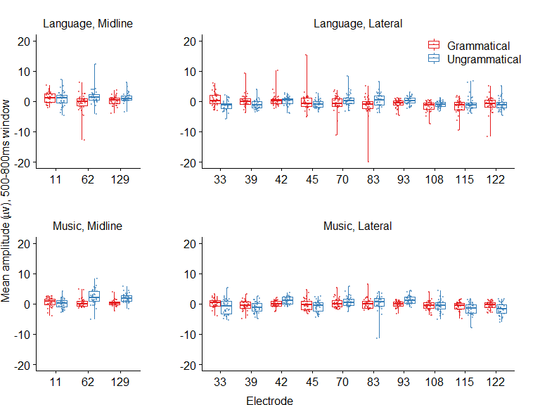

```r
language.midline.plot <- ggplot(language.midline.data, aes(x=electrode,y=mean.amplitude,color=grammar.condition)) +
  geom_point(position=position_jitterdodge(), alpha = 0.5, size=0.5)+
  scale_color_brewer(type="qual", palette="Set1", guide=F)+
  coord_cartesian(ylim=c(-20,20))+
  geom_boxplot(stat="boxplot", coef=Inf, fill=NA)+
  #labs(x="Electrode", y=expression("Mean amplitude ( "*mu*"v), 500-800ms"), title="Language Stimuli, Midline Electrodes")
  labs(x=NULL,y=NULL, title="Language, Midline")+
  theme(plot.title = element_text(face="plain", size=12))
language.lateral.plot <- ggplot(language.lateral.data, aes(x=electrode,y=mean.amplitude,color=grammar.condition)) +
  geom_point(position=position_jitterdodge(), alpha = 0.5, size=0.5)+
  scale_color_brewer(type="qual", palette="Set1", name=NULL)+
  coord_cartesian(ylim=c(-20,20))+
  geom_boxplot(stat="boxplot", coef=Inf, fill=NA)+
  #labs(x="Electrode", y=expression("Mean amplitude ( "*mu*"v), 500-800ms"), title="Language Stimuli, Midline Electrodes")
  labs(x=NULL,y=NULL, title="Language, Lateral")+
  theme(plot.title = element_text(face="plain", size=12), legend.position = c(0.7, 0.9))
music.midline.plot <- ggplot(music.midline.data, aes(x=electrode,y=mean.amplitude,color=grammar.condition)) +
  geom_point(position=position_jitterdodge(), alpha = 0.5, size=0.5)+
  scale_color_brewer(type="qual", palette="Set1", guide=F)+
  coord_cartesian(ylim=c(-20,20))+
  geom_boxplot(stat="boxplot", coef=Inf, fill=NA)+
  #labs(x="Electrode", y=expression("Mean amplitude ( "*mu*"v), 500-800ms"), title="Language Stimuli, Midline Electrodes")
  labs(x=NULL,y=NULL, title="Music, Midline")+
  theme(plot.title = element_text(face="plain", size=12))
music.lateral.plot <- ggplot(music.lateral.data, aes(x=electrode,y=mean.amplitude,color=grammar.condition)) +
  geom_point(position=position_jitterdodge(), alpha = 0.5, size=0.5)+
  scale_color_brewer(type="qual", palette="Set1", guide=F)+
  coord_cartesian(ylim=c(-20,20))+
  geom_boxplot(stat="boxplot", coef=Inf, fill=NA)+
  #labs(x="Electrode", y=expression("Mean amplitude ( "*mu*"v), 500-800ms"), title="Language Stimuli, Midline Electrodes")
  labs(x=NULL,y=NULL, title="Music, Lateral")+
  theme(plot.title = element_text(face="plain", size=12))
anova.plot <- plot_grid(language.midline.plot, language.lateral.plot, music.midline.plot, music.lateral.plot, ncol=2,nrow=2, rel_widths = c(1,2.5), rel_heights=c(1,1), scale=0.9) +
  draw_label("Electrode", size=12, y=0, vjust=0) +
  draw_label(expression("Mean amplitude ("*mu*"v), 500-800ms window"), size=12, x=0, vjust=1, angle=90)
ggsave("anova-data.png", plot=anova.plot, device = "png", path="figures/", width=8, height = 6.5, units = "in", dpi=300)
anova.plot
```

## Difference wave analysis comparing music and language directly

We analyze the difference between language and music P600s. Our pre-registration describes the analysis:

> Repeated-measures ANOVA, 2 (language v. music) x N (where N = the number of relevant electrodes; see below), of the mean amplitude of the difference wave forms (ungrammatical - grammatical) will be conducted in the 500 to 800 msec separately for lateral and midline electrodes.

First we calculate the difference waves (ungrammatical - grammatical) for each subject in each condition.

```r
difference.waves <- eeg.data %>%
  group_by(subject, electrode, t, stimulus.condition) %>%
  mutate(difference.voltage = voltage - lag(voltage)) %>%
  filter(!is.na(difference.voltage)) %>%
  select(subject, t, electrode, stimulus.condition, difference.voltage) %>%
  ungroup()
```

Plot of the difference waves.

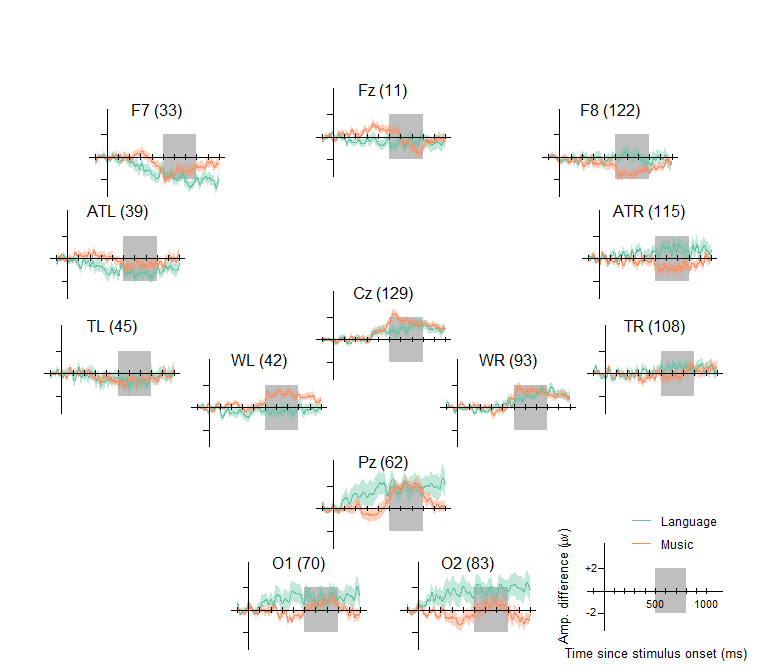

```r
difference.wave.grand.average.data <- difference.waves %>% group_by(t, electrode, stimulus.condition) %>%
  summarize(mean.voltage = mean(difference.voltage), sd.voltage = sd(difference.voltage), se.voltage = sd.voltage / sqrt(n()))
dw.make.plot <- function(plotting.data){
  p <- ggplot(plotting.data, aes(x=t, y=mean.voltage, color=stimulus.condition))+
    scale_color_brewer(name="Stimulus Type", type="qual", palette="Set2", guide=F)+
    scale_fill_brewer(guide=F, type="qual", palette="Set2")+
    annotate("rect", xmin=500,xmax=800,ymin=-2,ymax=2,fill='black',alpha=0.25)+
    coord_cartesian(ylim=c(min(difference.wave.grand.average.data$mean.voltage - difference.wave.grand.average.data$se.voltage), max(difference.wave.grand.average.data$mean.voltage + difference.wave.grand.average.data$se.voltage)))+
    geom_ribbon(mapping=aes(ymin=mean.voltage - se.voltage, ymax = mean.voltage + se.voltage, fill=stimulus.condition), color=NA, alpha = 0.4)+
    geom_line()+
    geom_vline(xintercept=0)+
    geom_hline(yintercept=0)+
    geom_segment(data = ticks, aes(x=x,y=y,xend=xend,yend=yend), color="black")+
    geom_segment(x=-50, y=2, xend=0,yend=2, color="black")+
    geom_segment(x=-50, y=-2, xend=0,yend=-2, color="black")+
    theme_void()
  return(p)
}
dw.legend.plot <- ggplot(difference.wave.grand.average.data, aes(x=t, y=mean.voltage, color=stimulus.condition))+
  geom_blank()+
  theme_void()+
  geom_vline(xintercept=0)+
  geom_hline(yintercept=0)+
  annotate("rect", xmin=500,xmax=800,ymin=-2,ymax=2,fill='black',alpha=0.25)+
  scale_color_brewer(guide=F)+
  geom_segment(data = ticks, aes(x=x,y=y,xend=xend,yend=yend), color="black")+
  annotate("text", label="500", x=500, y = -1.0, size=3)+
  annotate("text", label="1000", x=1000, y = -1.0, size=3)+
  geom_segment(x=-50, y=2, xend=0,yend=2, color="black")+
  geom_segment(x=-50, y=-2, xend=0,yend=-2, color="black")+
  coord_cartesian(ylim=c(min(difference.wave.grand.average.data$mean.voltage - difference.wave.grand.average.data$se.voltage), max(difference.wave.grand.average.data$mean.voltage + difference.wave.grand.average.data$se.voltage)), xlim=c(-100,1100))
dw.condition.legend <- (ggplot(difference.wave.grand.average.data, aes(x=t,y=mean.voltage,color=stimulus.condition))+
  geom_line()+
  theme_minimal(base_size = 11)+
  scale_color_brewer(palette="Set2", type="seq", name=NULL)) %>%
  get_legend()
dw.plots <- difference.wave.grand.average.data %>% group_by(electrode) %>% nest() %>% mutate(plot = map(data, dw.make.plot)) %>% right_join(electrode.locations)
dw.scale.factor.x <- (1 / (max(dw.plots$x) - min(dw.plots$x))) * 0.8
dw.scale.factor.y <- (1 / (max(dw.plots$y) - min(dw.plots$y))) * 0.8
dw.plots$x <- (dw.plots$x - 0.5) * dw.scale.factor.x + 0.5
dw.plots$y <- (dw.plots$y - 0.5) * dw.scale.factor.y + 0.5
dw.x.size <- .2
dw.y.size <- .15
dw.scalp <- ggplot(dw.plots) +
  geom_blank() +
  theme_void() +
  theme(plot.margin = unit(c(8,8,8,8), "pt"))
for(i in 1:nrow(dw.plots)){

  dw.scalp <- dw.scalp +
    annotation_custom( grob = ggplotGrob(dw.plots$plot[[i]]), xmin = dw.plots$x[[i]] - x.size/2, xmax = dw.plots$x[[i]] + x.size/2, ymin = dw.plots$y[[i]] - y.size/2, ymax = dw.plots$y[[i]] + y.size/2) +
    annotation_custom(grob = textGrob(dw.plots$name[[i]]), xmin = dw.plots$x[[i]] - x.size/2, xmax = dw.plots$x[[i]] + x.size/2, ymin = dw.plots$y[[i]] + y.size/2 - 0.02, ymax = dw.plots$y[[i]] + y.size/2 + 0.02)
}
dw.scalp <- dw.scalp +
  annotation_custom(grob = ggplotGrob(dw.legend.plot), xmin = 1.0 - x.size, xmax=1.0, ymin = 0, ymax= y.size) +
  annotation_custom(grob = textGrob("Time since stimulus onset (ms)", just="right", gp=gpar(fontsize=10)), xmin = .94, xmax =1.13 , ymin =-0.04 , ymax = -0.03 ) +
  annotation_custom(grob = textGrob(expression("Amp. difference ("*mu*"v)"), rot=90, gp=gpar(fontsize=10)), xmin = .74, xmax =.79 , ymin =0.04 , ymax = 0.11 ) +
  annotation_custom(grob = textGrob(expression("+2"), gp=gpar(fontsize=8)), xmin = .80, xmax =.81 , ymin =0.105 , ymax = 0.115 ) +
  annotation_custom(grob = textGrob(expression("-2"), gp=gpar(fontsize=8)), xmin = .80, xmax =.81 , ymin =0.03 , ymax = 0.04 ) +
  annotation_custom(grob = dw.condition.legend, xmin = 0.85, xmax = 1.0, ymin= 0.1, ymax = 0.25)
dw.scalp
```

#### Midline electrodes ANOVA

```r
midline.difference.data <- difference.waves %>%
  filter(electrode %in% midline.electrodes, t %in% p600.time.window) %>%
  group_by(subject, electrode, stimulus.condition) %>%
  summarize(mean.amplitude = mean(difference.voltage)) %>%
  as.data.frame()
midline.difference.anova <- ezANOVA(midline.difference.data, dv=mean.amplitude, wid=subject, within=c('stimulus.condition','electrode'))
midline.difference.anova$ANOVA
```

|  | Effect | DFn | DFd | F | p | p<.05 | ges |
| --- | --- | --- | --- | --- | --- | --- | --- |
| 2 | stimulus.condition | 1 | 34 | 0.2261587 | 6.374281e-01 |  | 0.001426070 |
| 3 | electrode | 2 | 68 | 16.2888392 | 1.660536e-06 | * | 0.120421080 |
| 4 | stimulus.condition:electrode | 2 | 68 | 0.3152952 | 7.306343e-01 |  | 0.003329377 |

#### Lateral electrodes ANOVA

```r
lateral.difference.data <- difference.waves %>%
  filter(electrode %in% lateral.electrodes, t %in% p600.time.window) %>%
  group_by(subject, electrode, stimulus.condition) %>%
  summarize(mean.amplitude = mean(difference.voltage)) %>%
  as.data.frame()
lateral.difference.anova <- ezANOVA(lateral.difference.data, dv=mean.amplitude, wid=subject, within=c(stimulus.condition,electrode))
lateral.difference.anova$ANOVA
```

|  | Effect | DFn | DFd | F | p | p<.05 | ges |
| --- | --- | --- | --- | --- | --- | --- | --- |
| 2 | stimulus.condition | 1 | 34 | 1.784931 | 1.904190e-01 |  | 0.002027262 |
| 3 | electrode | 9 | 306 | 12.180533 | 1.816049e-16 | * | 0.100114976 |
| 4 | stimulus.condition:electrode | 9 | 306 | 2.009149 | 3.796737e-02 | * | 0.033709656 |

#### Plotting data used for ANOVA

[figure not shown]

```r
dw.midline.plot <- ggplot(midline.difference.data, aes(x=electrode,y=mean.amplitude, color=stimulus.condition)) +
  geom_hline(yintercept=0, alpha=0.3)+
  geom_boxplot(stat="boxplot", coef=Inf, fill="white")+
  geom_point(position=position_jitterdodge(), alpha = 0.5, size=0.5)+
  scale_color_brewer(type="qual", palette="Set2", guide=F)+
  coord_cartesian(ylim=c(-25,25))+
  #labs(x="Electrode", y=expression("Mean amplitude ( "*mu*"v), 500-800ms"), title="Language Stimuli, Midline Electrodes")
  labs(x=NULL,y=NULL, title="Language, Midline")+
  theme(plot.title = element_text(face="plain", size=12))
dw.lateral.plot <- ggplot(lateral.difference.data, aes(x=electrode,y=mean.amplitude, color=stimulus.condition)) +
  geom_hline(yintercept=0, alpha=0.3)+
  geom_boxplot(stat="boxplot", coef=Inf, fill="white")+
  geom_point(position=position_jitterdodge(), alpha = 0.5, size=0.5)+
  scale_color_brewer(type="qual", palette="Set2", name=NULL)+
  coord_cartesian(ylim=c(-25,25))+
  #labs(x="Electrode", y=expression("Mean amplitude ( "*mu*"v), 500-800ms"), title="Language Stimuli, Midline Electrodes")
  labs(x=NULL,y=NULL, title="Language, Lateral")+
  theme(plot.title = element_text(face="plain", size=12), legend.position = c(0.7, 0.9))
dw.anova.plot <- plot_grid(dw.midline.plot, dw.lateral.plot, ncol=2,nrow=1, rel_widths = c(1,2.5), scale=0.9) +
  draw_label("Electrode", size=12, y=0, vjust=0) +
  draw_label(expression("Amp. difference ("*mu*"v), 500-800ms window"), size=12, x=0, vjust=1, angle=90)
ggsave("difference-waves-anova-data.png", plot=dw.anova.plot, device = "png", path="figures/", width=8, height = 3.5, units = "in", dpi=300)
dw.anova.plot
```

#### Bayes factors

Using BayesFactor package with default prior on fixed and random effects. Our pre-registration says:

> We will also analyze this second model using Bayes factors to evaluate relative support for the null finding of no difference in Patel v. the alternative hypothesis of a moderate effect. In the absence of any strong prior beliefs about the size of a difference between music and language P600s, we will use the default prior of the BayesFactor R package (r scaling factor = 0.5) to represent the prior on the fixed effects in a Bayesian repeated-measures ANOVA.

Estimating the BFs is stochastic. Setting a seed for the random number generator should create reproducible numbers.

```r
set.seed(12604)
bf.anova.midline <- anovaBF(mean.amplitude ~ stimulus.condition * electrode + subject, data= midline.difference.data, whichRandom = "subject")
summary(bf.anova.midline)
```

```
Bayes factor analysis
--------------
[1] electrode + subject                                                     : 18159.5  ±1.26%
[2] stimulus.condition + subject                                            : 0.17028  ±2.03%
[3] electrode + stimulus.condition + subject                                : 3015.209 ±1.32%
[4] electrode + stimulus.condition + electrode:stimulus.condition + subject : 366.7383 ±2.02%

Against denominator:
  mean.amplitude ~ subject
---
Bayes factor type: BFlinearModel, JZS
```

BF for model with electrode only vs. electrode + stimulus

```r
extractBF(bf.anova.midline)$bf[1] / extractBF(bf.anova.midline)$bf[3]
```

```
[1] 6.022635
```

```r
set.seed(12604)
bf.anova.lateral <- anovaBF(mean.amplitude ~ stimulus.condition * electrode + subject, data= lateral.difference.data, whichRandom = "subject")
summary(bf.anova.lateral)
```

```
Bayes factor analysis
--------------
[1] electrode + subject                                                     : 1805050268 ±0.35%
[2] stimulus.condition + subject                                            : 0.1569758  ±2.03%
[3] electrode + stimulus.condition + subject                                : 292564041  ±1.22%
[4] electrode + stimulus.condition + electrode:stimulus.condition + subject : 1236960130 ±1.3%

Against denominator:
  mean.amplitude ~ subject
---
Bayes factor type: BFlinearModel, JZS
```

BF for model with electrode only vs. full model.

```r
extractBF(bf.anova.lateral)$bf[1] / extractBF(bf.anova.lateral)$bf[4]
```

```
[1] 1.459263
```

```r
extractBF(bf.anova.lateral)$bf[4] / extractBF(bf.anova.lateral)$bf[3]
```

```
[1] 4.227998
```